# R Notebook

Question 1.

Load in the libraries you need, and look at the backpack data. Take note of variable names and dimensions.

#Load the libraries needed

```r
library(ggplot2)
library(CodeClanData)
library(tidyverse)
```

#Look data table

```r
backpack
```

| backpack_weight | body_weight | ratio | back_problems | major | year | sex | status | units |
| --- | --- | --- | --- | --- | --- | --- | --- | --- |
| 9 | 125 | 0.0720000 | 1 | Bio | 3 | Female | U | 13 |
| 8 | 195 | 0.0410256 | 0 | Philosophy | 5 | Male | U | 12 |
| 10 | 120 | 0.0833333 | 1 | GRC | 4 | Female | U | 14 |
| 6 | 155 | 0.0387097 | 0 | CSC | 6 | Male | G | 0 |
| 8 | 180 | 0.0444444 | 0 | EE | 2 | Female | U | 14 |
| 5 | 240 | 0.0208333 | 0 | History | 0 | Male | G | 0 |
| 8 | 170 | 0.0470588 | 0 | CM | 3 | Male | U | 15 |
| 4 | 185 | 0.0216216 | 1 | ARCE | 5 | Female | U | 18 |
| 5 | 130 | 0.0384615 | 0 | Bio | 4 | Female | U | 14 |
| 2 | 120 | 0.0166667 | 0 | Bio | 5 | Female | U | 8 |

[output cut: 90 more lines]

#Variable names = backpack_weight, body_weight, ratio, back_problems, major, year, sex, status, units Dimensions = 100 rows x 9 columns

Question 2.

What is the distribution of backpack weights that students are carrying? Choose an appropriate graph to show the distribution.

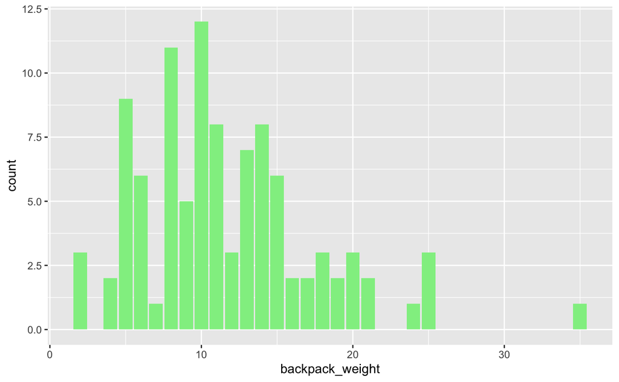

```r
ggplot(backpack) +
  geom_bar(aes(x = backpack_weight), fill = "light green")
```

#The above is a distribtion of count of number of students who have aweight of backpack (unspecified units)

Question 3.

Are there differences in backpack weight between sex?

weight of backpack by sex

```r
count_backpack <- backpack %>%
  group_by(backpack_weight, sex) %>%
  summarise(counts = n())
count_backpack
```

| backpack_weight | sex | counts |
| --- | --- | --- |
| 2 | Female | 2 |
| 2 | Male | 1 |
| 4 | Female | 1 |
| 4 | Male | 1 |
| 5 | Female | 6 |
| 5 | Male | 3 |
| 6 | Female | 3 |
| 6 | Male | 3 |
| 7 | Male | 1 |
| 8 | Female | 6 |

[output cut: 26 more lines]

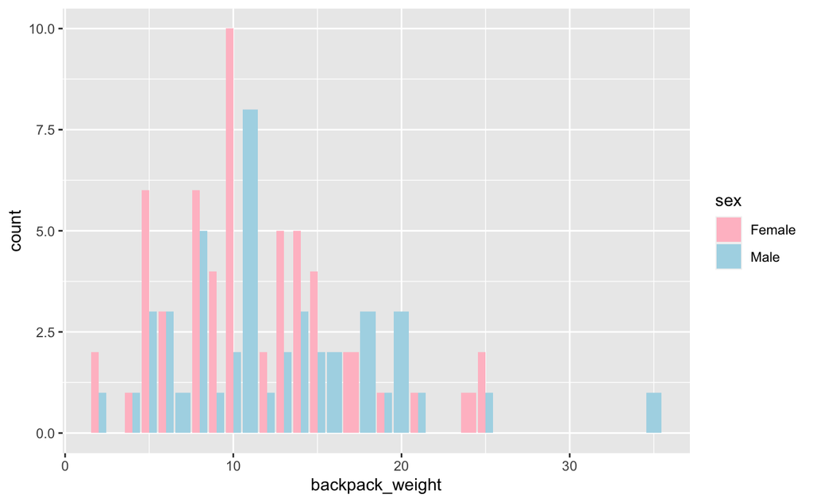

```r
ggplot(backpack) +
  geom_bar(aes(x = backpack_weight, fill = sex), position = "dodge") +
  scale_fill_manual(values = c("pink","light blue"))
```

#The above shows distribution of backpack weight vs count (number of students who have this backpack weight). This time sex is included in the graphs There is not a huge difference in backpack weights, although bear in mind there are more female students in this data sample. The one outlier, where weight > 30, is from a male student.

Question 4.

What is the relationship between body weight and backpack weight?

```
Ignoring unknown parameters: fill
```

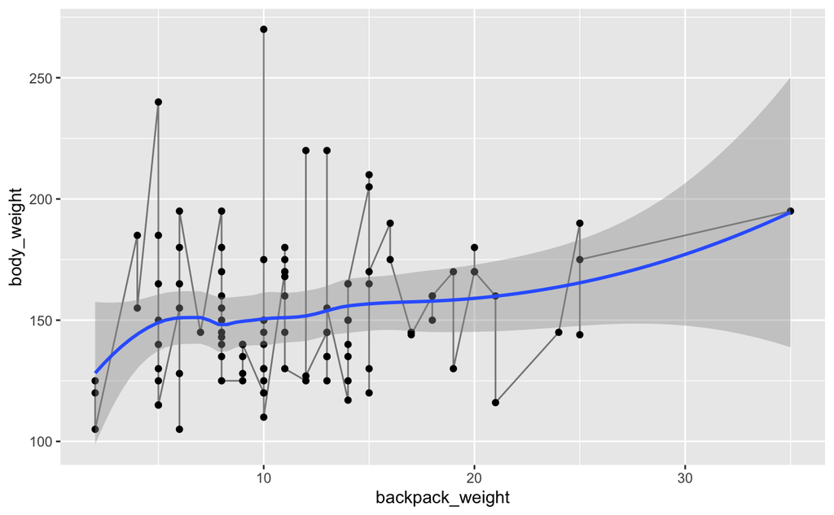

```r
ggplot(backpack) +
  geom_line(aes(x = backpack_weight, y = body_weight), fill = "blue",
  alpha = 0.5
  ) +
  geom_point(
    aes(x = backpack_weight, y = body_weight),
    alpha = 1
  ) +
  geom_smooth(
    aes(x = backpack_weight, y = body_weight)
  )
```

#Here we see a plot of backpack weights vs body weight. There are some wild fluctuations, however the overall trend is increase in backpack weight correlates with an increase in body weight.

Question 5.

Is this relationship different between men and women? Choose an appropriate plot and interpret your findings.

```
Ignoring unknown parameters: fill
```

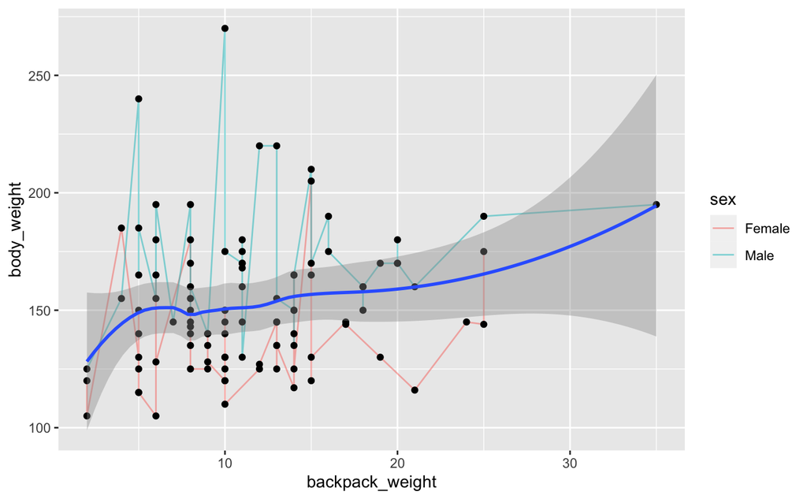

```r
ggplot(backpack) +
  geom_line(aes(x = backpack_weight, y = body_weight, colour = sex), fill = "blue",
  alpha = 0.5
  ) +
  geom_point(
    aes(x = backpack_weight, y = body_weight),
    alpha = 1
  ) +
  geom_smooth(
    aes(x = backpack_weight, y = body_weight)
  )
```

#Plot of backpack weight vs body weight showing male and female data separately. There is still a trend of increasing backpack weight to body weight however there is much more fluctauation in the body weight of males.

Question 6.

What proportion of students report back pain?

```r
backpack %>%
  select(back_problems)%>%
  sum
```

```
[1] 32
```

#Note I could have divided by number of rows but as it is trivially 100, the proportion is 32%

Question 7.

Is this proportion different between men and women?

```r
backpack %>%
  select(back_problems, sex)%>%
 filter(sex == "Male", back_problems == "1")
```

| back_problems | sex |
| --- | --- |
| 1 | Male |
| 1 | Male |
| 1 | Male |
| 1 | Male |
| 1 | Male |
| 1 | Male |
| 1 | Male |
| 1 | Male |

# 8 males have back problems

```r
backpack %>%
  select(sex) %>%
filter(sex == "Male")
```

| sex |
| --- |
| Male |
| Male |
| Male |
| Male |
| Male |
| Male |
| Male |
| Male |
| Male |
| Male |

[output cut: 35 more lines]

```r
ncol()
```

```
Error in ncol() : argument "x" is missing, with no default
```

The answer is yes. 8/45 males so 24/55 females, approximately 44% females to 17% males reported back problems

Question 8.

Now you’ve investigated your data separately, create plots to describe the relationship between backpack weight, body weight, gender and reported backpain.

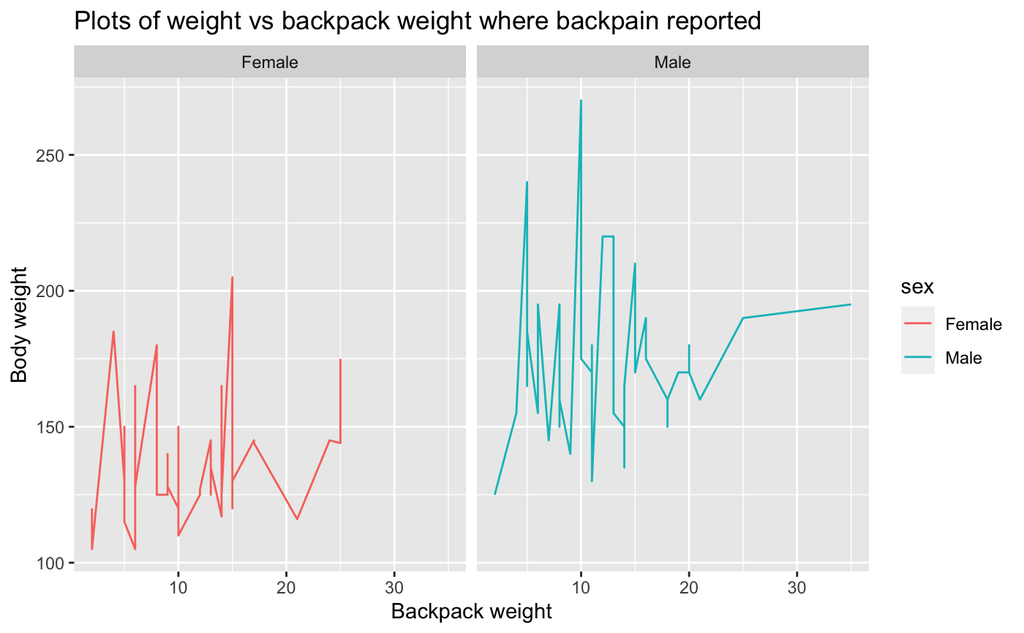

```r
ggplot(backpack) +
  aes(x = backpack_weight, y = body_weight, back_problems == 1, colour = sex) +
  geom_line() +
  facet_wrap(~ sex, ncol = 2) +
  labs(
    y = "Body weight",
    x = "Backpack weight",
    title = "Plots of weight vs backpack weight where backpain reported"
  )
```

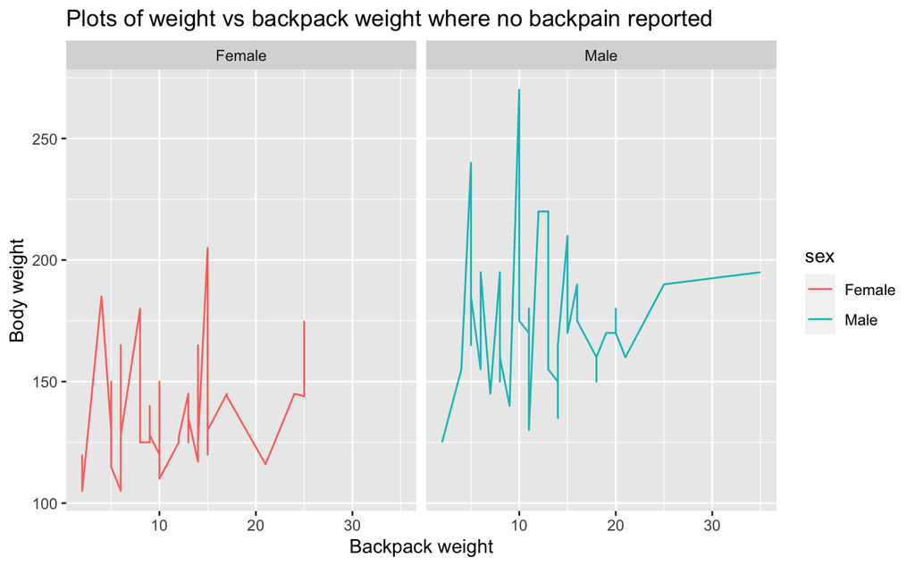

```r
ggplot(backpack) +
  aes(x = backpack_weight, y = body_weight, back_problems == 0, colour = sex) +
  geom_line() +
  facet_wrap(~ sex, ncol = 2) +
labs(
    y = "Body weight",
    x = "Backpack weight",
    title = "Plots of weight vs backpack weight where no backpain reported"
  )
```